# Gustavo Diaz – mpsa25_experimental

## Discussion: Proposals for and Applications of New Experimental Designs

- Jenke and Green. “Excludability is a Matter of Research Design: How to Conduct Credible Indirect Manipulations”
- Jordan, Ollerenshaw, Trexler. “New Evidence and Design Considerations for Repeated Measure Experiments”

Slides: talks.gustavodiaz.org/mpsa25_experimental

## Common theme

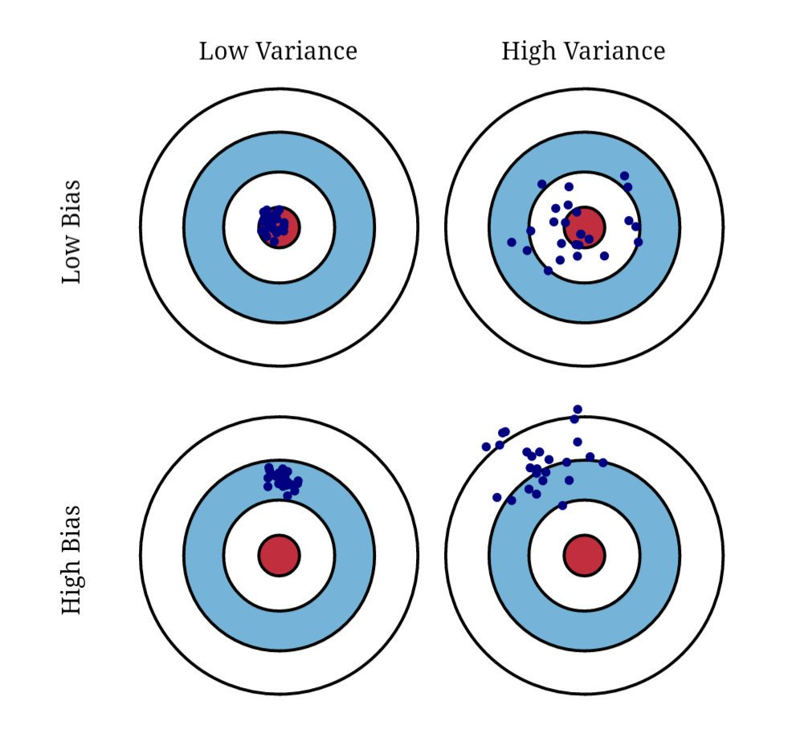

## But the game of darts is more complicated

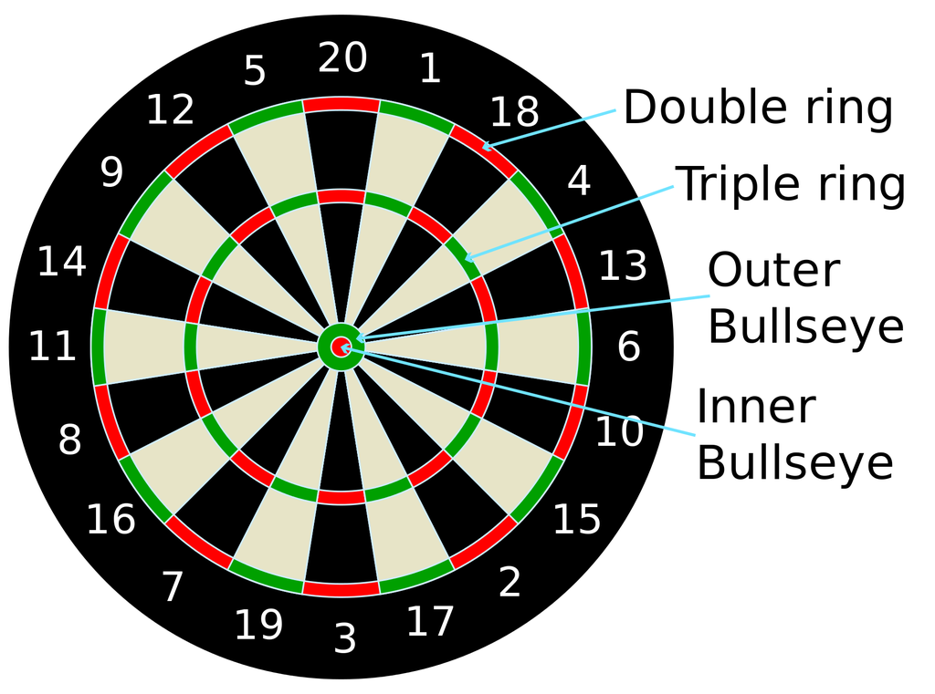

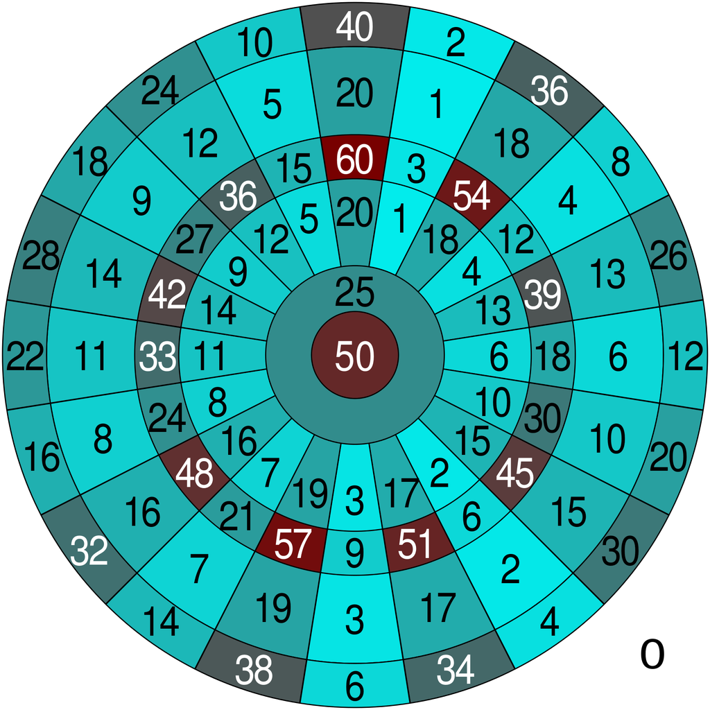

## Jenke and Green

**Why should you care?**

- EVERYTHING IS AN ENCOURAGEMENT DESIGN
- EVERYTHING VIOLATES THE EXCLUSION RESTRICTION
- EVERYTHING IS SUSCEPTIBLE TO PTOVB

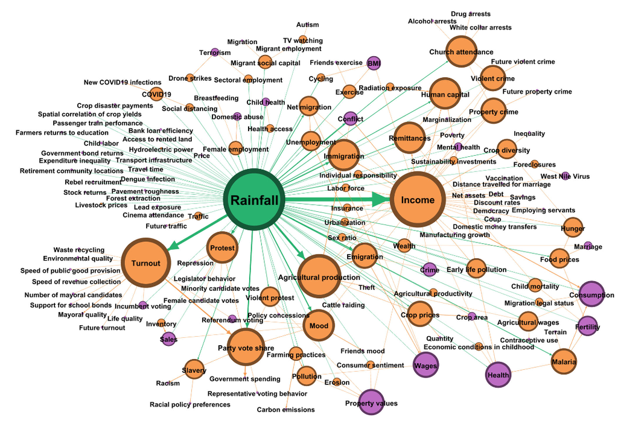

**Source:** [Mellon (2024, AJPS, Figure 2)](https://doi.org/10.1111/ajps.12894)

## Jenke and Green

**Why should you care?**

- EVERYTHING IS AN ENCOURAGEMENT DESIGN
- EVERYTHING VIOLATES THE EXCLUSION RESTRICTION
- EVERYTHING IS SUSCEPTIBLE TO PTOVB

**Things I like**

- Big picture framing
- Notation and math easy to follow
- Simulations nail the idea perfectly (cf. fig 2)

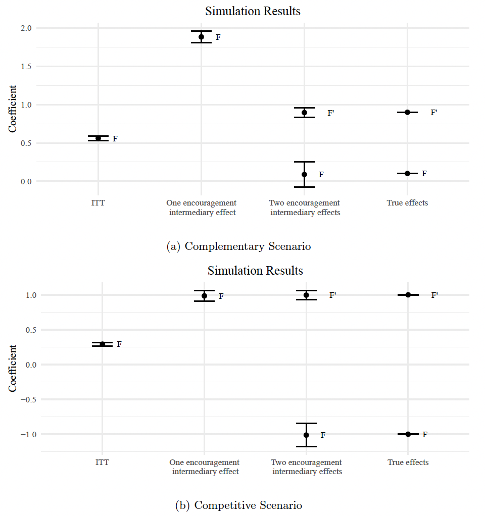

## Jenke and Green

**Questions and comments**

- (PT)OVB is always a problem no matter what you do
- Why not (a special kind of) sensitivity analysis?
- Bias-variance trade-off on the number of $Z^{\prime}$, $F^{\prime}$?
- Placebo outcomes? (If $Z$ does not affect $Y^{\prime}$, then $Z^{\prime}$ is unlikely)
- **Clarify:** Requirement is (at least) as many $Z^{\prime}$ as $F^{\prime}$, not necessarily one per each (mismatch theory/application)

## Jordan, Ollerenshaw, Trexler

**Why should you care?**

$$SE(\widehat{ATE}) = \sqrt{\frac{\color{#4E2A84}{\text{Var}(Y_i(0)) + \text{Var}(Y_i(1)) + 2\text{Cov}(Y_i(0), Y_i(1))}}{\color{#00843D}{N-1}}}$$

- Easiest way to increase statistical precision with a larger sample size
- But usually cost prohibitive!
- In many applications, the only way is to reduce variance in outcomes through research design

## Jordan, Ollerenshaw, Trexler

**Why should you care?**

Standard experiment:

$$\widehat{ATE} = E[Y_i(1) | Z_i = 1] - E[Y_i(0) | Z_i(0)]$$

```r
lm(Y ~ Z, data = data) # or just difference in means
```

Repeated measures design (between groups):

$$\widehat{ATE} = E[(Y_{i,t=2}(1) \color{#4E2A84}{- Y_{i,t=1}}) | Z_i = 1] - E[(Y_{i,t=2}(0) \color{#4E2A84}{- Y_{i,t=1}}) | Z_i = 0]$$

```r
lm(Y_t2 ~ Z + Y_t1, data = data)
```

## Jordan, Ollerenshaw, Trexler

**Things I like**

- Partial replication! (replication + extension?)
- Different samples
- Thinking carefully about implementation decisions (e.g. proximity of repeated measures)
- Honesty about limitations (e.g. sensitive questions)

## Jordan, Ollerenshaw, Trexler

**Questions and comments**

- Help the reader visualize your randomizations
- Repeating repeated measures creates attenuation bias. Why exactly? Inattention? Priming?
- Replicate/simulate more diverse studies? [(Harden et al 2019)](https://doi.org/10.1017/pan.2018.54)
- If repeated measures are just covariate adjustment, why not using [Lin’s (2013)](https://doi.org/10.1214/12-AOAS583) adjustment for more precision? (s/o Ransi Clark)

Also, citation to Diaz (2025) should be [Diaz and Rossiter (2025)](https://gustavodiaz.org/files/research/precision_retention.pdf)